# Informe Sobre Estudio de Felicidad

Andrés Lepiz- Jose Pablo - Xenia Guerrero

2020-07-03

# Antecedentes.

## Procedimiento realizado:

Para el desarrollo del análisis se siguió el siguiente procedimiento:

- Recepción del archivo con los datos generales
- Separación de datos con el año a analizar
- Definición de las variables a tomar en cuenta. Para esta tarea se tomó en cuenta lo siguiente:
  - La experiencia de cambio de felicidad durante el transcurso del tiempo (2015-2018), según el World Happiness Report, ahí se pudo observar que el sentimiento de felicidad fue cambiando conforme pasaba el tiempo.
  - Se pensó en diferentes aristas que pudieran involucrar varios aspectos concretos para la definición de felicidad dichas aristas contemplaron:
    - Aspectos Sociales
    - Aspectos Económicos
    - Salud
    - Democracia
  - Tomando en cuenta el punto anterior, de las 15 variables que se tenían a disposición se eligieron 4 saber:
    - log_gdp_per_capita (Económico)
    - social_support (Social)
    - healthy_life_expectancy_at_birth (Salud)
    - freedom_to_make_life_choices (democracia)

## Resultados:

### 1. Aplicación de Algoritmo en Excel

El resultado es el siguiente luego de aplicar k=3 y 4 iteraciones

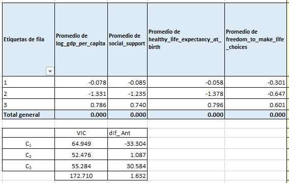

```r
knitr::include_graphics("C:/Tarea/Imagenxls.jpg")
```

### 2. Ejecución de Algoritmo kmedias en R

```r
set.seed(101)
library(readxl)
library(xlsx)
df<-read_excel("C:/Tarea/Datos.xlsx")
#print(df)
str(df)
```

```
## tibble [140 x 5] (S3: tbl_df/tbl/data.frame)
##  $ Paises        : chr [1:140] "Afghanistan" "Albania" "Algeria" "Argentina" ...
##  $ Ingreso       : num [1:140] 7.5 9.28 9.55 9.65 8.99 ...
##  $ Social_support: num [1:140] 0.559 0.638 0.748 0.883 0.709 ...
##  $ Expec_Vida    : num [1:140] 49.9 68.7 64.8 67.4 65.4 ...
##  $ Libertad      : num [1:140] 0.523 0.73 0.587 0.848 0.611 ...
```

```r
knitr::kable(summary(df))
```

|  | Paises | Ingreso | Social_support | Expec_Vida | Libertad |
| --- | --- | --- | --- | --- | --- |
|  | Length:140 | Min. : 2.736 | Min. :0.2902 | Min. :43.38 | Min. :0.3035 |
|  | Class :character | 1st Qu.: 8.248 | 1st Qu.:0.7521 | 1st Qu.:57.08 | 1st Qu.:0.6843 |
|  | Mode :character | Median : 9.486 | Median :0.8402 | Median :64.79 | Median :0.7749 |
|  | NA | Mean : 9.200 | Mean :0.8121 | Mean :62.88 | Mean :0.7614 |
|  | NA | 3rd Qu.:10.227 | 3rd Qu.:0.9112 | 3rd Qu.:68.92 | 3rd Qu.:0.8635 |
|  | NA | Max. :11.459 | Max. :0.9849 | Max. :76.41 | Max. :0.9838 |

```r
df$Paises = row.names(df$Paises)
df<-scale(df)
#descarga del archivo escalado para hacer luego el ejercicio de cálculo de distances en excel
write.xlsx(df, file="mydataxe1.xlsx")
dfk3<-kmeans(df, centers = 3, nstart = 50)
```

### 3. Resultado de los centroides generados en R

```r
dfk3$centers
```

```
##      Ingreso Social_support Expec_Vida   Libertad
## 1  0.1061505     0.08979014  0.1676175 -0.4712726
## 2 -1.2690680    -1.14241875 -1.3490518 -0.4014843
## 3  0.8265907     0.75021233  0.8206238  0.7966474
```

### 4. Cálculo de Distancias en Excel.

Luego de aplicar el algoritmo en R se tomó la decisión de descargar de R la información de los centroides y la tabla de datos escalada esto con en fin de definir las distancias en Excel. El resultado fue el siguiente:

- Tabla de Centroides:

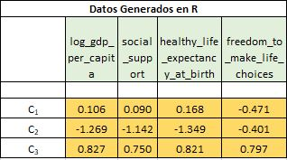

```r
knitr::include_graphics("C:/Tarea/centroides.jpg")
```

- Cálculo de Distancias: Se determina que la cantidad de países por cada centro es la siguiente:
  - C1 53
  - C2 37
  - C3 50

### 4. Interpretación final de Resultados.

Para la interpretación de cada cluster y según los datos obtenidos se sefinión cada uno como: + El Cluster más feliz + El Cluster con nivel medio de Felicidad + El Cluster menos feliz

A continuación se describe el detalle de cada uno de los cluster.

#### 1. Cluster (Medio)

[output not shown]

Un primer ejemplo es Azerbaijan, donde en 2016 hay varios escenarios de persecución a críticos del gobierno, abogados y restricción de libertad de prensa según Human Rights Watch, sin embargo, no hay datos notables con respecto a deficiencias en temas de salud, educación ni pobreza extrema. Otro caso similar es Egipto, donde los principales problemas son alrededor de restricción de libertad de religión, expresión y prensa, así como discriminación por género y orientación sexual según Human Rights Watch. Por último, el tercer representante más notable del grupo es Macedonia, donde el evento más relevante está alrededor de las protestas generadas por el pueblo solicitando la renuncia del primer ministro. Aunque hubo cierto nivel de violencia, las protestas no pasaron a nivel de Guerra civil, aunque sí se habla de un cierto grado de represión por parte del gobierno a los protestantes.

#### 2. Cluster (Más tristes)

[output not shown]

Guinea, Liberia & Sierra Leone países más afectados por el ébola que inició en 2014, con un total de muertes entre los 3 países de 11310 personas según Centers of Disease Control and Prevention. También, según el reporte anual del 2016 de UNICEF, Guinea mantuvo uno de los índices de mortalidad materna y mortalidad infantile. Igualmente se reportaba que más de la mitad de la población viven en pobreza extrema y es uno de los países con mayor corrupción y la tensión política y social aumentaban desde que el gobierno anterior continuaba retrasando las elecciones del 2015 aún para el 2016. Para el caso de Camerún, que es un país colonizado principalmente por alemanes, británicos y franceses, levantan un problema de índole social y política conocido como el problema anglófono, en el que se ponen en evidencia las desigualdades sociales entre la parte autodenominada anglófona y la francesa, que en 2016 generara una serie de protestas violentas. En temas de salud, el VIH continua siendo uno de los principales problemas en éste año. En Niger, el 2016 fue un año electoral lleno de diversos conflictos (pocos violentos), mientras tanto una inundación que desbordara los principales ríos del país arrasó con más de 9000 hogares. Otro gran problema es la cantidad de matrimonios con niñas (76% de los matrimonios son con mujeres menores de 17 años y al menos un 25% antes de los 15 según el reporte de UNICEF), a lo que se le suma un 82.5% de malnutrición infantil. También es un país con exceso de personas jóvenes, resultado de embarazos infantiles y falta de planificación, donde la mayoría de los mismos no tienen acceso a la educación y por lo tanto están destinados a la pobreza.

#### 3. Cluster (Más Feliz)

[output not shown]

Los 3 países mejor posicionados son:

Czech Republic, este país ha invertido en la elaboración de una estrategia denominada “La Estrategia de Competitividad que pretende posicionar a dicho país entre los primeros 20 países en competitividad económica hacia 2020.” Y pretende entre otros mejorar en gran medida la situación laboral. Aunque es un país que en los últimos años ha tenido índices de empleo superiores al promedio según la OCDE. (el 74% de la población en edad laboral (entre 15 y 64 años) tiene un empleo remunerado). También la estrategia tiene componentes que favorecen la educación.

En Portugal, aunque su economía se vio impactada por la crisis financiera global 2011-2013, se ha venido levantando poco a poco con políticas que favorecen mucho la innovación y el emprendimiento, uno de los aspectos a los que se le atribuye un índice algo en felicidad es que la mayoría de las personas tienen trabajos remunerados y acceso a educación de calidad, esto mejora la calidad de vida en todos sus aspectos.

Para el caso de Polonia se tiene que país donde la seguridad personal, así como la educación y competencias se ha venido mejorando con el tiempo y se encuentra por encima del promedio en seguridad personal, así como en educación y competencias, la medición de aspectos de salud, ingresos, compromiso cívico, empleo y remuneración están un poco bajos, pero eso no ha afectado la percepción de felicidad. En la parte de políticas se potencia el apoyo a pequeñas y medianas empresas también se ha invertido en desarrollo de políticas educativas y el impulso a uso y desarrollo de tecnologías verdes

### Anexo- Resultado Gráfico

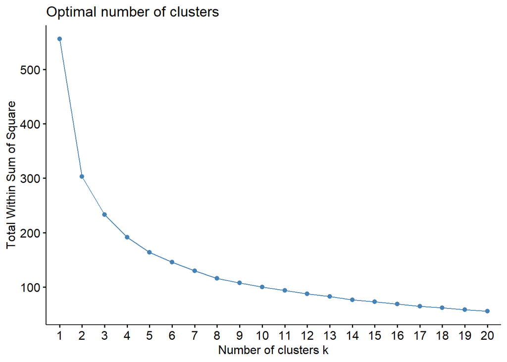

```r
library(factoextra)
fviz_nbclust(x=df, FUNcluster=kmeans, method = "wss", k.max=20,
             diss=get_dist(df, method="euclidean"), nstart=50)
```

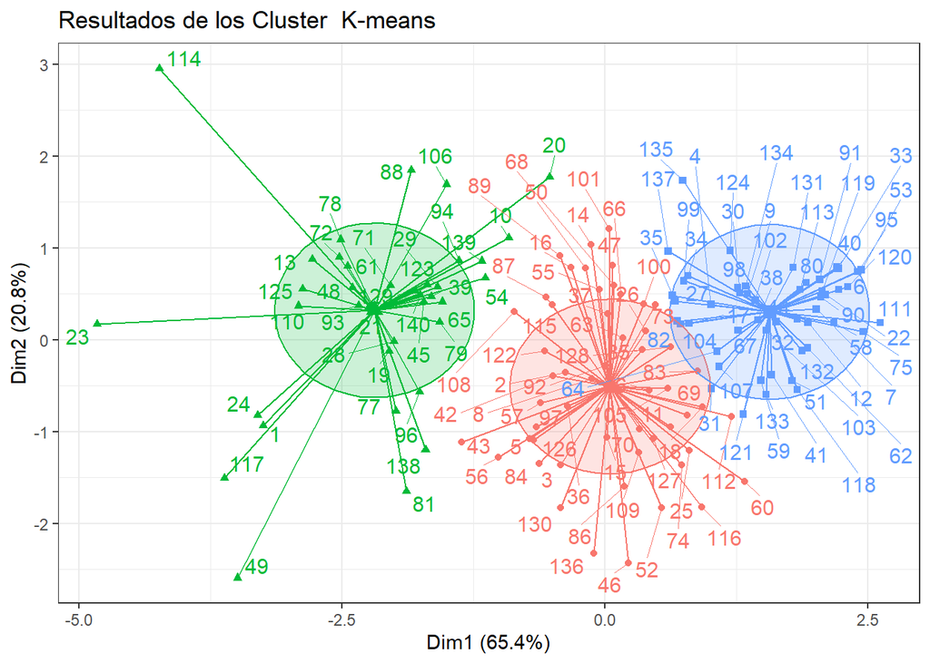

```r
km_clusters <- kmeans(x = df, centers = 3, nstart = 50)

# Las funciones del paquete factoextra emplean el nombre de las filas del

fviz_cluster(object = km_clusters, data = df, show.clust.cent = TRUE,
             ellipse.type = "euclid", star.plot = TRUE, repel = TRUE) +
  labs(title = "Resultados de los Cluster  K-means") +
  theme_bw() +
  theme(legend.position = "none")
```